# Data Exploration Project

Rahul Bharadwaj Mysore Venkatesh - 31322239

21/08/2020

# **Introduction -**

University ranking is a measurable outcome of multiple factors that are considered to evaluate the standard of education, faculty, resources, and infrastructure. Every year, Universities are ranked by different organizations around the world like CWUR, Times Higher Education, Quacquarelli Symmonds (QS) and many others. We are using a dataset that contains rankings of the world universities as maintained by QS.

Quacquarelli Symmonds (QS) is a British think-tank company specializing in the analysis of higher education institutions throughout the world. It uses 6 factors for their ranking framework wiz. Academic Reputation, Employer Reputation, Faculty to Student Ratio, Number of Citations per Faculty, International Faculty, International Students. Another feature included in this data was Classification (which is not used for ranking) which included the institution’s size, subject range, research intensity, age, and status.

This Data Exploration Project is an effort to answer some questions around the analysis of higher education institutions such as the following –

1. What factors other than rank is more desirable when deciding the quality of a University? In other words, how do Universities compare in terms of the 6 factors in QS factor classification?
2. Which Universities top in each of the specific factors?
3. Is there a correlation between different classification factors like Country, Age of the University, Reputation of the University, Size and International Student Numbers?

# **Data Description -**

- Kaggle link for dataset - https://www.kaggle.com/divyansh22/qs-world-university-rankings.
- It is a Tabular Data: 1K rows x 22 columns. It has simple text in the form of “.csv”
- For the purpose of our analysis, we make use of only the top 100 Universities of the world as it seems to have rich data and people are usually more likely to compare among the top 100.
- The Tools and Technologies used for this Project are Microsoft Excel, R & RStudio, and Tableau.

# **Data Wrangling -**

**visdat: Visualizing Whole Data Frames in R - by Nicholas Tierney**

- visdat() is an R package that has a variety of functions to visualize datasets and give a visual overview of the dataset of interest. We read the data into R environment after filtering top 100 observations in Microsoft Excel and use the clean data.

```r
#reading the data
Uni2020 <- read.csv(here::here("Data/Clean/2020-QS-World-University-Rankings.csv"))
```

- The raw data has all columns in character format, and we convert it into appropriate types using the following procedure in RStudio.

```r
TopUni2020 <- Uni2020 %>% select(-Rank.in.2019) %>% mutate(
                   SIZE = as.factor(SIZE),
                   FOCUS = as.factor(FOCUS),
                   RESEARCH.INTENSITY = as.factor(RESEARCH.INTENSITY),
                   AGE = as.factor(AGE),
                   STATUS = as.factor(STATUS),
                   AcademicSCORE = as.double(AcademicSCORE),
                   EmpSCORE = as.double(EmpSCORE),
                   RatioSCORE = as.double(RatioSCORE),
                   CiteSCORE = as.double(CiteSCORE),
                   IntFacSCORE = as.double(IntFacSCORE),
                   IntStuSCORE = as.double(IntStuSCORE),
                   AcademicRANK = as.integer(AcademicRANK),
                   EmpRANK = as.integer(EmpRANK),
                   RatioRANK = as.integer(RatioRANK),
                   CiteRANK = as.integer(CiteRANK),
                   IntFacRANK = as.integer(IntFacRANK),
                   IntStuRANK = as.integer(IntStuRANK),
                   Overall.Score = as.double(Overall.Score))
```

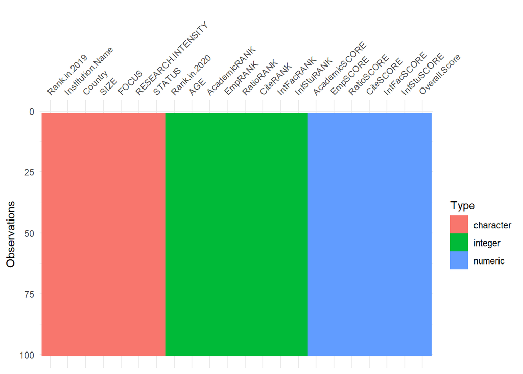

Initial Dataset Visualization with Datatypes

- The above visualization shows column names on x-axis and number of observations on y-axis. The ‘Type’ legend displays the data type for the observations for corresponding columns.
- We can see that there are only 3 datatypes in the data. They are character, integer, and numeric. Some of the classification factors are converted into factor using as.factor() function in R.
- After checking the data for its types and missing values, we can move on to further data exploration and analysis. The following visualization shows the converted type after transformation in R.

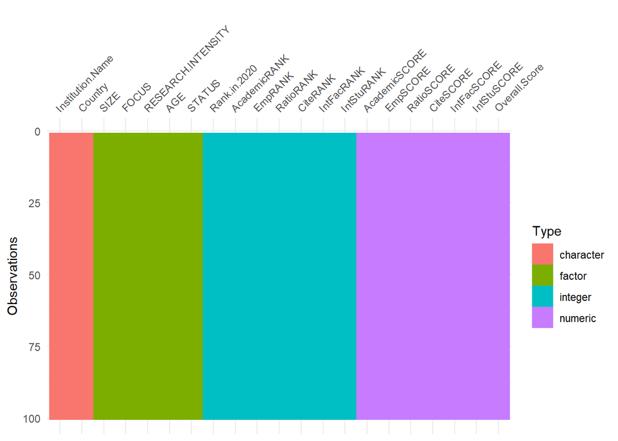

Tranformed Dataset Visualization with Datatypes

- The above figure shows that factor type is added for classification variables and 2019 rank column is deleted. This data is clean without any errors and is ready for exploration and analysis.

# **Data Checking -**

- Data checking is the process of scrutinizing the data before using it for analysis. Data can be checked both simply in the text form like in MS Excel or using advanced visual methods in R.
- Some packages in R are very useful to check the overall data and its types in each row and column as described in the previous section. Now, let’s check the simple text inconsistencies.
- Some of the manual cleaning done on MS Excel before transformations in R is as follows -

**A glimpse of the Raw Data is as follows –**

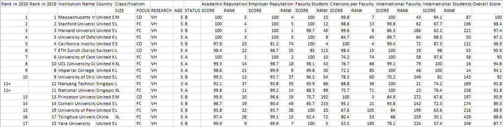

Raw Data in Excel

- On the first look, we can observe some main columns and sub columns for the 6 factors. Also, some records have inconsistent values in the “Rank in 2020” column like the 11th and 12th rank in the above example.
- Such small inconsistencies are first manually cleaned on MS Excel for easy processing in RStudio for further Analysis. After making manual changes, the clean data looks something like this –

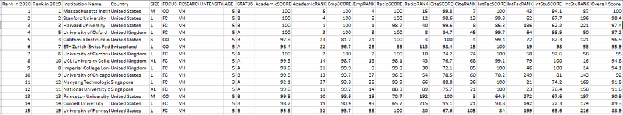

Cleaned Data in Excel

- We can observe that the sub column structure is made into a single column name structure and the inconsistent “Rank in 2020” column in corrected.
- Some columns related to 6 factor Ranks contained data such as 601+ which cannot be processed for operations in R. We find and replace all instances ‘601+’ with ‘601’. This data is clean enough to be further processed in RStudio and Tableau for further analysis.

# **Data Exploration -**

- Data Exploration is the process of making sense of the data through visualizations. It not only helps us answer the questions defined for the analysis, but also helps us discover new insights we did not intend to find that can be useful.
- It sometimes helps us find insights about new things and formulate new questions that can further enhance the details about the primary answers to the questions defined beforehand.
1. **What factors other than rank is more desirable when deciding the quality of a University? How do Universities compare in terms of the 6 factors in QS factor classification? Which University tops in each of the specific factors?**

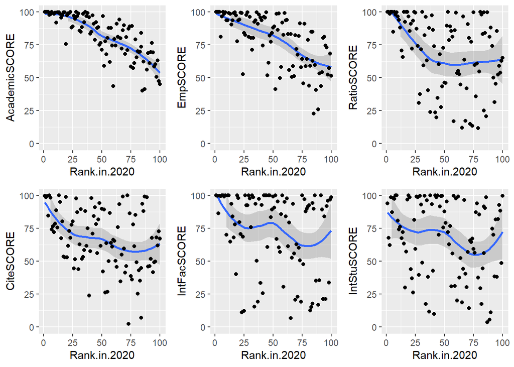

Correlation between Rank of the University and 6 factors

- From the figure above, Academic Reputation and Employer Reputation Scores have a negative correlation as the Rank value increases from 1-100. This means that better the University rank, better is the Academic Quality and Employers seek graduates from top universities in general.
- Faculty to Student Ratio and Citations per Faculty are somewhat similar after the 35th Rank and shows lesser correlation than the previous two factors.
- International Faculty and Student Scores are not correlated with rank and show bimodal distribution with the increase in rank value from 1-100.
- Thus, we can say that Academic Reputation and Employer Reputation are the factors other than rank that decides the quality of an institution in general.
2. **Which Universities top in each of the specific factors?**
- We consider the Universities that have a Score of 100/100 in each factor. The numbering in the plot represents the world university ranking in the QS list for that university.

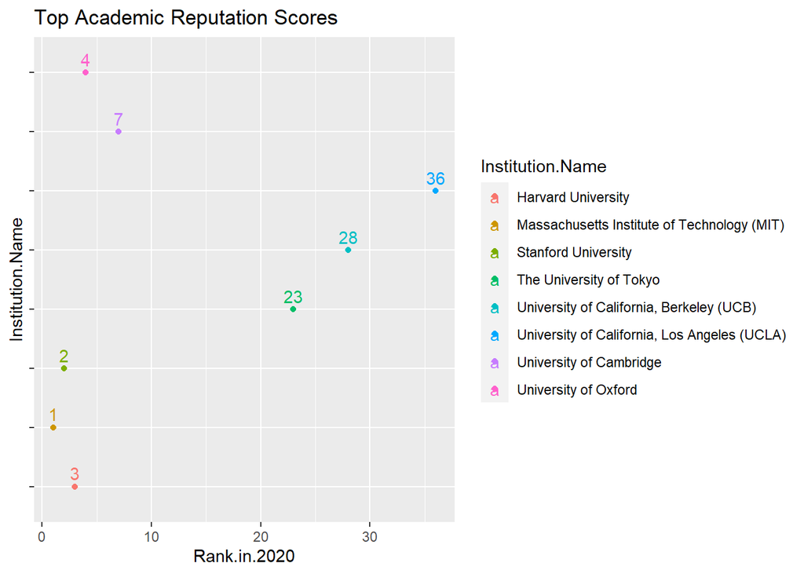

[output not shown]

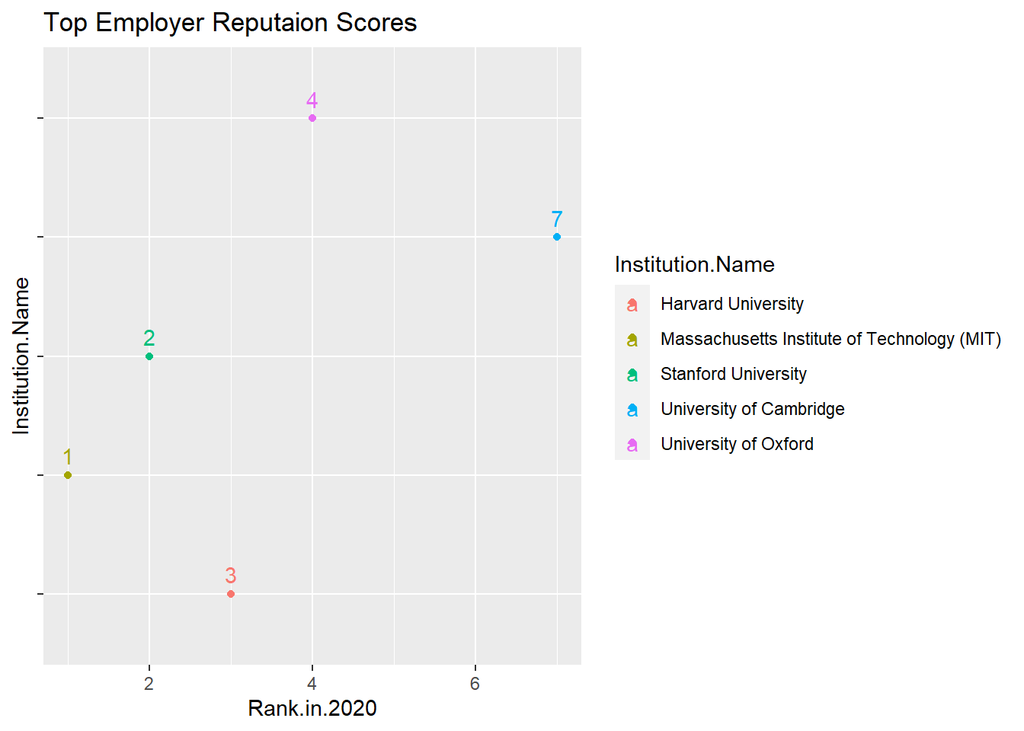

[output not shown]

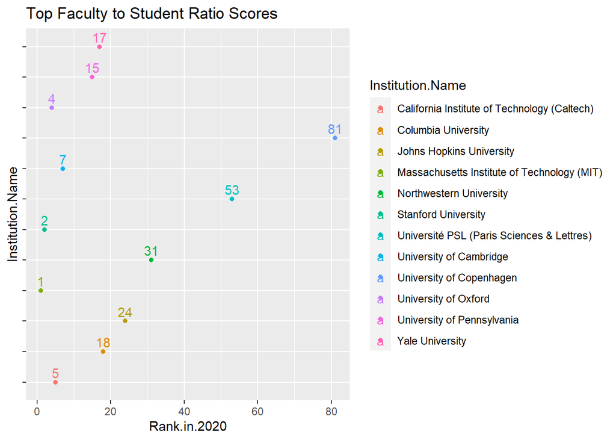

[output not shown]

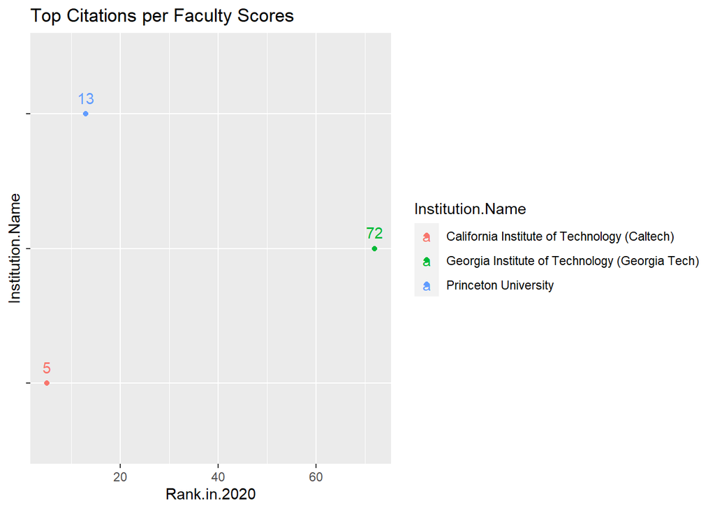

[output not shown]

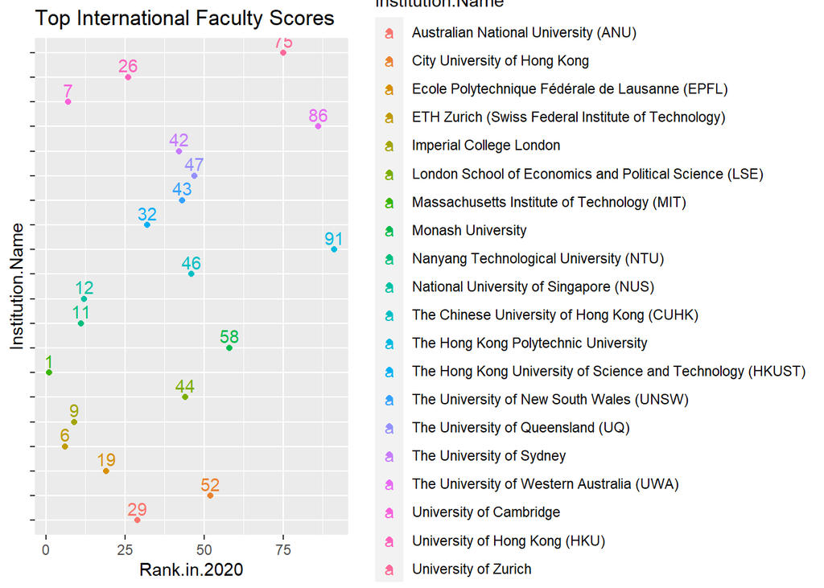

[output not shown]

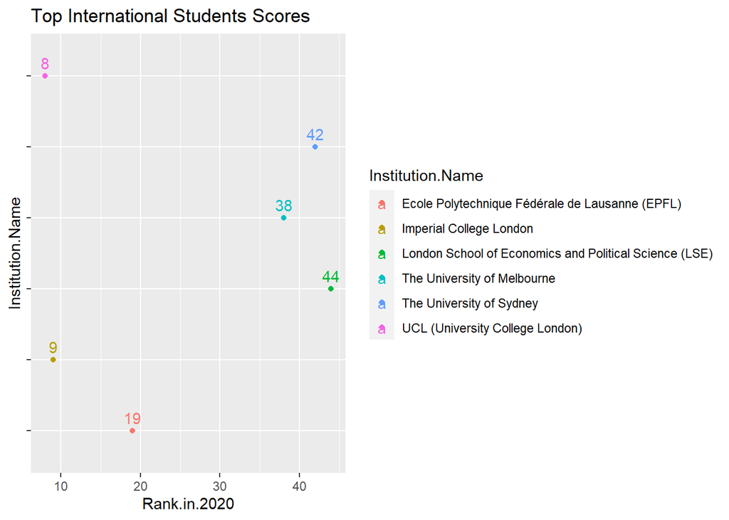

[output not shown]

- The top universities in each factor are listed above and this answers our question as to which is best in what factor. We can make a choice based on the kind of environment we’re looking for in a university and the factor that matters most to us.
3. **Is there a correlation between institution size and number of international students? Is there a relationship between age of the university and its reputation?**
- Distribution of Top 100 Universities in each country.

[figure not shown]

Country-wise Frequency Distribution of the Top 100 Universities in QS World Rankings.

[output not shown]

- **Is there a relationship between age of the university and its employer reputation?**

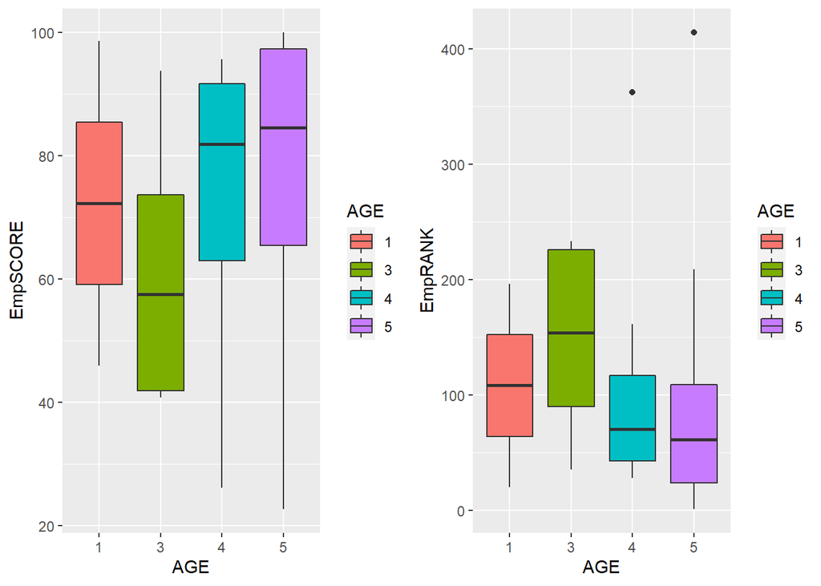

Age versus Employer Reputation of Universities

```
                              5 = Greater than 100 years old (Historic Universities)
                              4 = 50-100 years old (Mature Universities)
                              3 = 25-50 years old (Established Universities)
                              1 and 2 = Less than 25 years old (Young Universities)
```

- We can see that generally the historic and mature universities have better employer reputation. A higher SCORE and lower RANK is the desirable reading which is mostly found in the older universities. Thus, employer reputation generally increases with the age of the university.
- **Is there a relationship between institution size and number of international students?**

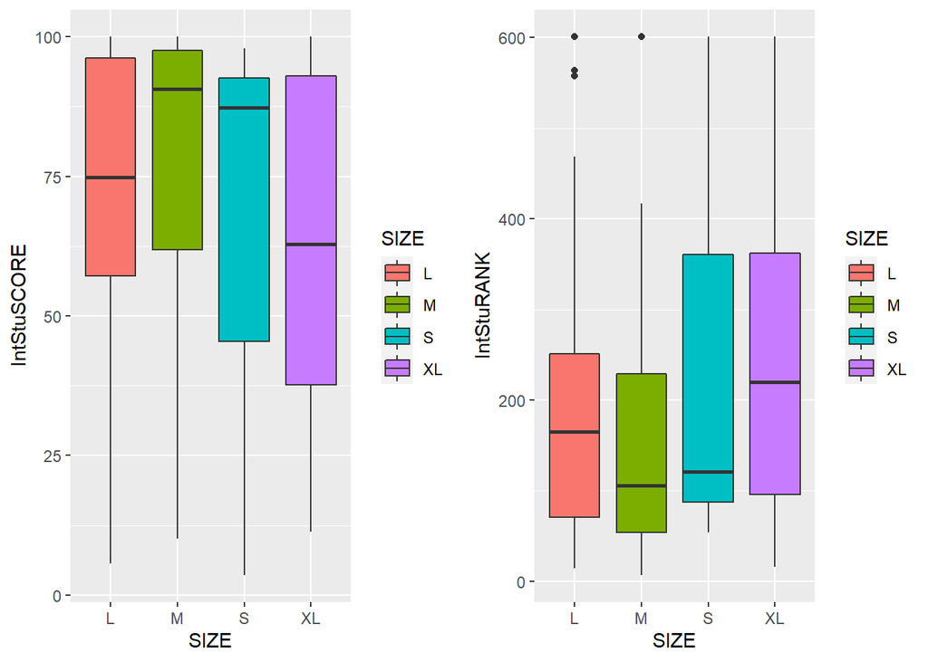

Size versus International Student Scores and Rank

```
                                        XL = Greater than 30,000
                                         L = Greater than 12,000
                                         M = Greater than  5,000
                                         S = Lesser  than  5,000
```

- We can observe that the Small (S) and Medium (M) sized universities have the greatest diversity among students with a greater number of international students compared to Large (L) and Extra Large (XL) sized universities. They have a desirable reading of higher SCORE and lower RANK values. Thus, a higher number of students count does not mean that there will be more diversity in the student population.

# **Conclusion -**

From the Data Exploration and Visualization conducted in the previous section, we can conclude that –

- Academic Reputation and Employer Reputation are the factors other than rank that decides the quality of an institution in general. A high ranked University is generally good in Academic and Employer Reputation factors.
- Each University has its own factor of strength. It is not necessary for the Top Universities to have strength in all factors. There is a different list of Top Universities for each category of factors. Individuals need to assess what factors matter most to them and make a choice of institution.
- US, UK, and Australia have the greatest number of Universities in the Top 100 QS list.
- Employer reputation generally increases with the age of the university. Also, some of the young institutions have a better employer reputation than the established ones. This shows the quality of Young institutions is good in general.
- Size of the university does not indicate its diversity. Smaller and Medium sized Universities have more International Students in comparison with Large and Extra-Large Universities.

# **References -**

- Software Used –
  - Microsoft Corporation. (2018). Microsoft Excel. Retrieved from https://office.microsoft.com/excel
  - RStudio Team. (2015). RStudio: Integrated Development Environment for R. Boston, MA. Retrieved from http://www.rstudio.com/
  - Tableau (Version 2020.2) [Windows]. Chabot, C., Stolte, C., Beers, A., & Hanrahan, P. (2020). Mountain View, California: Salesforce. Retrieved from https://www.tableau.com/
- R Packages –
  - Wickham et al., (2019). Welcome to the tidyverse. Journal of Open Source Software, 4(43), 1686, https://doi.org/10.21105/joss.01686
  - Kirill Müller (2017). here: A Simpler Way to Find Your Files. R package version 0.1. https://CRAN.R-project.org/package=here
  - Tierney N (2017). “visdat: Visualising Whole Data Frames.” *JOSS*, *2*(16), 355. doi: 10.21105/joss.00355 (URL: https://doi.org/10.21105/joss.00355)
  - H. Wickham. ggplot2: Elegant Graphics for Data Analysis. Springer-Verlag New York, 2016.
  - Alboukadel Kassambara (2020). ggpubr: ‘ggplot2’ Based Publication. Ready Plots. R package version 0.4.0. https://CRAN.R-project.org/package=ggpubr